# Part I - Data Exploration of NYC's Citi Bike Sharing System (2022)

## Introduction

> Citi bike is a privately owned bicycle sharing system serving the New York City and New Jersey. The company has been acquired by Lyft and uses technologies by Lyft in its stations and operations. Named after lead sponsor Citigroup, It officially opened in May 2013 with 332 stations and 6,000 bikes. By October 2017 annual expansions brought the totals to 706 stations and 12,000 bikes, making the service the largest bike sharing program in the United States.

## Preliminary Wrangling

```python
# import all packages and set plots to be embedded inline
import numpy as np
import pandas as pd
import matplotlib.pyplot as plt
import seaborn as sb
import datetime as dt
from math import sin, cos, sqrt, atan2

%matplotlib inline
```

### Gathering and Importing Data.

> Lyft operates New York City’s Citi Bike bicycle sharing service and is committed to supporting bicycling as an alternative transportation option. As part of that commitment, Lyft makes certain Citi Bike system data available to the public. Published downloadable files of the Citi bike trip data are made available [here](https://s3.amazonaws.com/tripdata/index.html). The scope of study is to analyse 2022 bike sharing data. Files containing data for each of the months in that year have been dowloaded. Data of each month will be merged to form a complete and single dataset for the year 2022.

```python
jan = pd.read_csv("202201-citibike-tripdata.csv", low_memory=False)
feb = pd.read_csv("202202-citibike-tripdata.csv", low_memory=False)
mar = pd.read_csv("202203-citibike-tripdata.csv", low_memory=False)
apr = pd.read_csv("202204-citibike-tripdata.csv", low_memory=False)
may = pd.read_csv("202205-citibike-tripdata.csv", low_memory=False)
jun = pd.read_csv("202206-citbike-tripdata.csv", low_memory=False)
jul = pd.read_csv("202207-citbike-tripdata.csv", low_memory=False)
aug = pd.read_csv("202208-citibike-tripdata.csv", low_memory=False)
sep = pd.read_csv("202209-citibike-tripdata.csv", low_memory=False)
octo = pd.read_csv("202210-citibike-tripdata.csv", low_memory=False)
nov = pd.read_csv("202211-citibike-tripdata.csv", low_memory=False)
dec = pd.read_csv("202212-citibike-tripdata.csv", low_memory=False)
```

```python
df = pd.concat([jan, feb, mar, apr,may, jun,jul, aug, sep, octo, nov,dec], ignore_index=True)
```

### Assesment

> All the data needed for this exploratory analysis have been sourced, loaded and merged into a single dataset (df). This is followed by the assessment of the dataset to check for all isues that might be relating to the tidiness and quality of the data. The assessment will be done in two ways:
> - Programatic Assessment
> - Visual Assesment

### Programatic Assesment

```python
# Checking the data type of each attribute.
df.info()
```

```
<class 'pandas.core.frame.DataFrame'>
RangeIndex: 30689921 entries, 0 to 30689920
Data columns (total 13 columns):
 #   Column              Dtype
---  ------              -----
 0   ride_id             object
 1   rideable_type       object
 2   started_at          object
 3   ended_at            object
 4   start_station_name  object
 5   start_station_id    object
 6   end_station_name    object
 7   end_station_id      object
 8   start_lat           float64
 9   start_lng           float64
 10  end_lat             float64
 11  end_lng             float64
 12  member_casual       object
dtypes: float64(4), object(9)
memory usage: 3.0+ GB
```

```python
# Checking if there are null values
df.isna().sum()
```

```
ride_id                   0
rideable_type             0
started_at                0
ended_at                  0
start_station_name       50
start_station_id         50
end_station_name      71773
end_station_id        71773
start_lat                 0
start_lng                 0
end_lat               37516
end_lng               37516
member_casual             0
dtype: int64
```

```python
# Number of records and attributes in our data
df.shape
```

```
(30689921, 13)
```

```python
# assessing the unique values to know cateries with our data
df.nunique()
```

```
ride_id               30689921
rideable_type                3
started_at            15958668
ended_at              15962290
start_station_name        1761
start_station_id          1749
end_station_name          1841
end_station_id            1829
start_lat              1217574
start_lng               900322
end_lat                   2676
end_lng                   2663
member_casual                2
dtype: int64
```

```python
# checking the membership categories
df.member_casual.unique()
```

```
array(['member', 'casual'], dtype=object)
```

```python
# checking the types of bikes available for riders
df.rideable_type.unique()
```

```
array(['classic_bike', 'electric_bike', 'docked_bike'], dtype=object)
```

### Visual Assessment

> for futher assessment, visual scrutiny is also necessary to spot if there are irregularities in the data. This is done by sampling randomly 20 rows and assessing them visually.

```python
df.sample (20)
```

|  | ride_id | rideable_type | started_at | ended_at | start_station_name | start_station_id | end_station_name | end_station_id | start_lat | start_lng | end_lat | end_lng | member_casual |
| --- | --- | --- | --- | --- | --- | --- | --- | --- | --- | --- | --- | --- | --- |
| 9525798 | EE8ACF56B09410D4 | classic_bike | 2022-06-29 17:51:03 | 2022-06-29 18:12:47 | Central Park S & 6 Ave | 6876.04 | E 106 St & Madison Ave | 7528.31 | 40.765909 | -73.976342 | 40.793434 | -73.949450 | member |
| 18646186 | 55C7198BF13D1D85 | electric_bike | 2022-08-10 07:34:33 | 2022-08-10 07:42:12 | W 29 St & 9 Ave | 6416.06 | W 42 St & 6 Ave | 6517.08 | 40.750073 | -73.998393 | 40.754920 | -73.984550 | member |
| 20862926 | 06D01456094A281E | electric_bike | 2022-09-10 13:14:32 | 2022-09-10 13:26:08 | Hanson Pl & Ashland Pl | 4395.07 | 3 Ave & Schermerhorn St | 4437.01 | 40.685068 | -73.977908 | 40.686832 | -73.979677 | casual |
| 9187796 | F6AB20BAE3BF4995 | electric_bike | 2022-05-05 15:54:31 | 2022-05-05 16:49:12 | Mt Morris Park W & W 120 St | 7685.14 | Dyckman St & Henshaw St | 8636.04 | 40.804038 | -73.945925 | 40.867357 | -73.929360 | member |
| 24861534 | 3A87CE9DBA7E87F4 | classic_bike | 2022-10-31 09:36:36 | 2022-10-31 09:40:53 | Bialystoker Pl & Delancey St | 5335.03 | Avenue D & E 3 St | 5436.09 | 40.716226 | -73.982612 | 40.720828 | -73.977932 | member |
| 30037936 | DCAA15C785CCA65E | classic_bike | 2022-12-06 10:14:36 | 2022-12-06 10:25:06 | E 118 St & 1 Ave | 7596.10 | Amsterdam Ave & W 119 St | 7727.07 | 40.797499 | -73.935053 | 40.808625 | -73.959621 | member |
| 26008925 | 05D6D104A2A85483 | classic_bike | 2022-10-26 11:34:45 | 2022-10-26 11:55:56 | Van Buren St & Broadway | 4568.01 | Hanson Pl & Ashland Pl | 4395.07 | 40.692000 | -73.926170 | 40.685068 | -73.977908 | casual |
| 9821208 | B41D5FD788957B35 | classic_bike | 2022-06-21 20:09:48 | 2022-06-21 20:12:55 | 48 St & Broadway | 6629.06 | 48 St & 37 Ave | 6435.02 | 40.755763 | -73.912715 | 40.751555 | -73.915026 | member |
| 7765420 | 4697CEB1405CD139 | electric_bike | 2022-05-31 07:33:32 | 2022-05-31 07:38:14 | 4 Ave & E 12 St | 5788.15 | W 18 St & 6 Ave | 6064.08 | 40.732647 | -73.990110 | 40.739713 | -73.994564 | member |
| 7149948 | 10C80C624C4D7EA3 | electric_bike | 2022-05-29 11:13:48 | 2022-05-29 11:21:45 | E 81 St & York Ave | 7084.12 | E 58 St & 1 Ave (NE Corner) | 6682.03 | 40.772838 | -73.949892 | 40.758924 | -73.962262 | member |
| 3310864 | 652DAD6B142633F9 | classic_bike | 2022-03-28 10:50:37 | 2022-03-28 10:57:39 | Howard St & Lafayette St | 5422.04 | Delancey St & Eldridge St | 5414.07 | 40.719105 | -73.999733 | 40.719383 | -73.991479 | member |
| 28884187 | 32A41BD4B9D49A37 | classic_bike | 2022-11-05 10:47:54 | 2022-11-05 10:51:06 | E 1 St & 1 Ave | 5593.01 | E 7 St & Avenue A | 5626.07 | 40.723356 | -73.988650 | 40.726218 | -73.983799 | member |
| 9455483 | 345A5209FCF7FAFA | classic_bike | 2022-06-25 23:33:56 | 2022-06-25 23:49:36 | S Portland Ave & Hanson Pl | 4354.05 | Butler St & Court St | 4339.01 | 40.685396 | -73.974315 | 40.684989 | -73.994403 | member |
| 17818565 | 4708510D37E15BC7 | classic_bike | 2022-08-26 20:47:40 | 2022-08-26 20:57:47 | 1 Ave & E 78 St | 7020.09 | 2 Ave & E 104 St | 7436.11 | 40.771404 | -73.953517 | 40.789211 | -73.943708 | member |
| 18218822 | 2DE75CD6CC6A2CDC | electric_bike | 2022-08-26 23:03:21 | 2022-08-26 23:29:52 | Stagg St & Union Ave | 5117.05 | Washington St & Gansevoort St | 6039.06 | 40.708771 | -73.950953 | 40.739323 | -74.008119 | member |
| 23939118 | A89D87F22C494892 | classic_bike | 2022-10-18 17:46:40 | 2022-10-18 18:00:37 | E 27 St & Park Ave S | 6131.13 | E 11 St & 1 Ave | 5746.14 | 40.742752 | -73.984716 | 40.729538 | -73.984267 | member |
| 15541022 | 77B84B7287D4DFAC | classic_bike | 2022-07-08 07:22:15 | 2022-07-08 07:23:33 | Columbus Ave & W 72 St | 7175.05 | Columbus Ave & W 72 St | 7175.05 | 40.777057 | -73.978985 | 40.777057 | -73.978985 | member |
| 11064192 | 8DB7FF0CB8A33133 | classic_bike | 2022-06-03 10:45:14 | 2022-06-03 11:06:34 | Allen St & Hester St | 5342.10 | W 20 St & 7 Ave | 6182.02 | 40.716059 | -73.991908 | 40.742388 | -73.997262 | member |
| 10600160 | 68EACE97F9A23D40 | classic_bike | 2022-06-29 19:05:54 | 2022-06-29 19:14:02 | Court St & State St | 4488.08 | 1 Pl & Clinton St | 4193.14 | 40.690238 | -73.992031 | 40.680959 | -73.999057 | member |
| 20772539 | 07ED8BF82CDF8350 | classic_bike | 2022-09-02 14:28:16 | 2022-09-02 14:44:42 | Pleasant Ave & E 116 St | 7450.05 | E 89 St & 3 Ave | 7265.10 | 40.794988 | -73.933335 | 40.780628 | -73.952167 | member |

### Cleaning

> To make the data tidy and ready for use the following issues will have to be resolved:
> 1. Remove all null values
> 2. replace the dot "." in the start station and end station ids.
> 3. Change the data format to date time type
> 4. identify the categorical column and change their data type.

#### Issue 1

#### Define

remove rows containing null values.

#### Code

```python
df.dropna(inplace = True)
```

#### Test

```python
df.isna().sum()
```

```
ride_id               0
rideable_type         0
started_at            0
ended_at              0
start_station_name    0
start_station_id      0
end_station_name      0
end_station_id        0
start_lat             0
start_lng             0
end_lat               0
end_lng               0
member_casual         0
dtype: int64
```

#### Issue 2

#### Define

remove the "." from the values in the station IDs

#### Code

```python
df.start_station_id = df.start_station_id.str.replace('.', '');
```

```python
df.end_station_id= df.end_station_id.str.replace('.', '');
```

#### Test

```python
df.head(3)
```

|  | ride_id | rideable_type | started_at | ended_at | start_station_name | start_station_id | end_station_name | end_station_id | start_lat | start_lng | end_lat | end_lng | member_casual |
| --- | --- | --- | --- | --- | --- | --- | --- | --- | --- | --- | --- | --- | --- |
| 0 | 55262E4365A955A2 | classic_bike | 2022-01-18 08:23:52 | 2022-01-18 08:28:18 | Boerum Pl\t& Pacific St | 448809 | Clinton St & Joralemon St | 460504 | 40.688489 | -73.991160 | 40.692395 | -73.993379 | member |
| 1 | D272F1B15D841EC0 | classic_bike | 2022-01-21 09:03:22 | 2022-01-21 09:05:44 | E 12 St & Ave C | 561608 | E 10 St & Avenue A | 565905 | 40.727243 | -73.976831 | 40.727408 | -73.981420 | member |
| 2 | D1FCEF55EB4A807F | classic_bike | 2022-01-22 14:28:32 | 2022-01-22 14:53:18 | W 21 St & 6 Ave | 614005 | W 44 St & 11 Ave | 675605 | 40.741740 | -73.994156 | 40.762009 | -73.996975 | member |

#### Issue 3

#### Define

change the dates from object type to timestamps to represent the datetime format.

#### Code

```python
df.started_at = pd.to_datetime(df.started_at)
df.ended_at = pd.to_datetime(df.ended_at)
```

#### Test

```python
df.info()
```

```
<class 'pandas.core.frame.DataFrame'>
Int64Index: 30618148 entries, 0 to 30689920
Data columns (total 13 columns):
 #   Column              Dtype
---  ------              -----
 0   ride_id             object
 1   rideable_type       object
 2   started_at          datetime64[ns]
 3   ended_at            datetime64[ns]
 4   start_station_name  object
 5   start_station_id    object
 6   end_station_name    object
 7   end_station_id      object
 8   start_lat           float64
 9   start_lng           float64
 10  end_lat             float64
 11  end_lng             float64
 12  member_casual       object
dtypes: datetime64[ns](2), float64(4), object(7)
memory usage: 3.2+ GB
```

#### Issue 3

#### Define

change the member_casual and rideable_type columns to category type

#### Code

```python
df.member_casual = df.member_casual.astype('category')
df.rideable_type = df.rideable_type.astype('category')
```

#### Test

```python
df.info()
```

```
<class 'pandas.core.frame.DataFrame'>
Int64Index: 30618148 entries, 0 to 30689920
Data columns (total 13 columns):
 #   Column              Dtype
---  ------              -----
 0   ride_id             object
 1   rideable_type       category
 2   started_at          datetime64[ns]
 3   ended_at            datetime64[ns]
 4   start_station_name  object
 5   start_station_id    object
 6   end_station_name    object
 7   end_station_id      object
 8   start_lat           float64
 9   start_lng           float64
 10  end_lat             float64
 11  end_lng             float64
 12  member_casual       category
dtypes: category(2), datetime64[ns](2), float64(4), object(5)
memory usage: 2.8+ GB
```

## Further Manipulation/ Wrangling

> From the timestamps, the hour of the day, day of the week, months and duration of the rides are cummulated. This will serve as a strong base for exploring our data.

### Hour of the day

```python
df['hr_started']= df.started_at.dt.hour
df.hr_started.sample(5)
```

```
18126595    17
11485295    13
17947102    20
2663714      6
14453917    17
Name: hr_started, dtype: int64
```

### Days of the Week

```python
df['dow_started']= df.started_at.dt.strftime('%a')
df.dow_started.sample(5)
```

```
5600385     Mon
21078672    Mon
7583258     Wed
12499953    Tue
5321776     Thu
Name: dow_started, dtype: object
```

### Months

```python
df['month'] = df.started_at.dt.strftime('%b')
df.month.sample(5)
```

```
29842929    Dec
22194460    Sep
15813569    Jul
14513367    Jul
2528777     Mar
Name: month, dtype: object
```

### Duration of travelling

```python
### check the diffence between the start time and end time
df['duration_sec'] = (df.ended_at - df.started_at).dt.total_seconds()
df['duration_minute'] = round(df['duration_sec']/60, 2)
df.duration_minute.head(3)
```

```
0     4.43
1     2.37
2    24.77
Name: duration_minute, dtype: float64
```

> All records showing duration above 24 hours are considered outliers. These outlier would be filtered out and dropped from the dataset in future sections

```python
# Filtering out the outliers
out_sec = df[df.duration_sec > 86400]
```

## Final Dataset

```python
df.info()
```

```
<class 'pandas.core.frame.DataFrame'>
Int64Index: 30618148 entries, 0 to 30689920
Data columns (total 18 columns):
 #   Column              Dtype
---  ------              -----
 0   ride_id             object
 1   rideable_type       category
 2   started_at          datetime64[ns]
 3   ended_at            datetime64[ns]
 4   start_station_name  object
 5   start_station_id    object
 6   end_station_name    object
 7   end_station_id      object
 8   start_lat           float64
 9   start_lng           float64
 10  end_lat             float64
 11  end_lng             float64
 12  member_casual       category
 13  hr_started          int64
 14  dow_started         object
 15  month               object
 16  duration_sec        float64
 17  duration_minute     float64
dtypes: category(2), datetime64[ns](2), float64(6), int64(1), object(7)
memory usage: 3.9+ GB
```

### What is the structure of your dataset?

> The dataset originally 13 columns and over 30 million rows
> - Ride ID: The unique Identifier of each ride
> - Rideable type: The type of bike
> - Started at: Time the ride started
> - Ended at : Time the ride ended
> - Start station name: The station the ride started
> - Start station ID: The start station the ride ID
> - End station name: The station the ride ended
> - End station ID: The end station ID
> - Start latitude
> - Start longitude
> - End latitude
> - End Longitude
> - Member or casual ride Additionally, columns were created from the above data to enable easy extraction of insights.
> - hr_started: The hour of the day the trip was started
> - dow_started: The day of the week ride was taken
> - month: The month of the ride
> - duration_sec: Time interval of bike sharing in seconds
> - duration_minute: Time interval of bike sharing in minutess

### What is/are the main feature(s) of interest in your dataset?

> The main features to explored in the dataset are:
> - The time of the day, week, month that bikes are mostly used.
> - what type of bike do riders prefer.
> - Which stations have the highest patronage.
> - Membership preference for ride type and timing.

### What features in the dataset do you think will help support your investigation into your feature(s) of interest?

> The features that will aid this exploration are hr_started, dow_started, month, duration_minute, member_casual, rideable_type.

## Univariate Exploration

> Certain Attribute of interest will be examined in our dataset. Questions will be asked and attributes will be visualised to know how values are distributed within the dataset. Both the categorical and numenic data wil be observed to understand bikers behaviour and preferences.

### How has the patronage been over the year

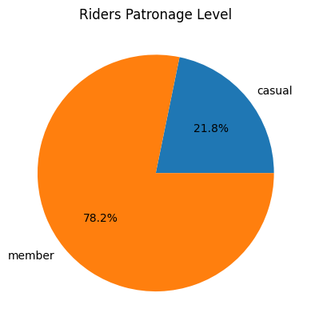

```python
membership = df.member_casual.value_counts()
membership.sort_values(ascending = True).plot(kind = 'pie',autopct='%1.1f%%', title = "Riders Patronage Level")
plt.ylabel("")
```

> The 2022 data shows that most of the rides were ordered by members. This could be a great turnout for citi bike sharing having known that 78 percent of its annual order came from members. This is also a sign that persons with membership have reasons to keep using the service. Citi bike sharing system have a number bike type within its structure. It will be nice to know the bikes most of its patron are using.

### What type of ride is most prefered by riders

```python
def countplot(feature, sequence):
    if sequence == None:
        base_color = sb.color_palette()[0]
        sb.countplot(data=df, x= feature, color = base_color)
    else:
        base_color = sb.color_palette()[0]
        sb.countplot(data=df, x= feature, color = base_color, order = sequence )
```

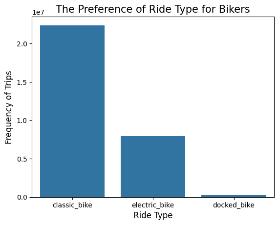

```python
bike_type = ['classic_bike', 'electric_bike', 'docked_bike']
countplot('rideable_type', bike_type)
plt.title("The Preference of Ride Type for Bikers",  fontsize=15, fontweight='medium')
plt.xlabel('Ride Type',  fontsize=12, fontweight='medium')
plt.ylabel('Frequency of Trips',  fontsize=12, fontweight='medium');
```

> The rideable bikes are the classic bikes, electric bikes and docked bikes. Riders have huge preference for the classic bikes. This may be as a result of the price which is beyond the scope of the study because price information have not been provided. Another reason might be that bikers use this as form of exercise. It will be good to know what are the time people prefer to ride.

### What time do riders mostly use Citi bike Service?

> - Hour of the day
> - Day of the week
> - Month of the year

#### Hour of the day

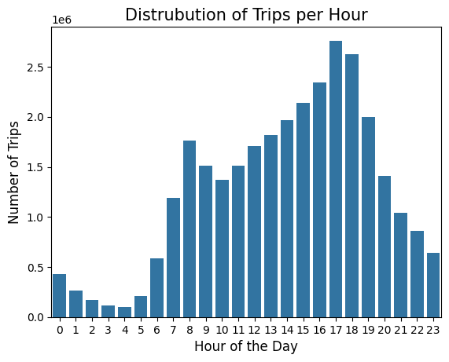

```python
countplot('hr_started', None)
plt.title("Distrubution of Trips per Hour", fontsize=15, fontweight='medium');
plt.xlabel('Hour of the Day', fontsize=12, fontweight='medium');
plt.ylabel('Number of Trips', fontsize=12, fontweight='medium');
```

> The time has helped identify the most likely period riders will come to the station. During the day, riders will mostly go the station in the evening. The visualisation shows that more riders will be at the station at closing hours in schools and work places between the time 2 to 7.

#### Day of the week

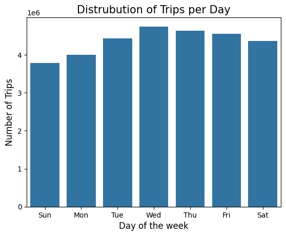

```python
days = [ 'Sun', 'Mon', 'Tue', 'Wed', 'Thu', 'Fri', 'Sat']
countplot('dow_started', days)
plt.title("Distrubution of Trips per Day", fontsize=15, fontweight='medium');
plt.xlabel('Day of the week', fontsize=12, fontweight='medium');
plt.ylabel('Number of Trips', fontsize=12, fontweight='medium');
```

> Most rides are ordered on Wednesdays, Thursdays and Fridays. The residents do not have preference for riding on weekends with sundays being the least day.

#### Month of the Year

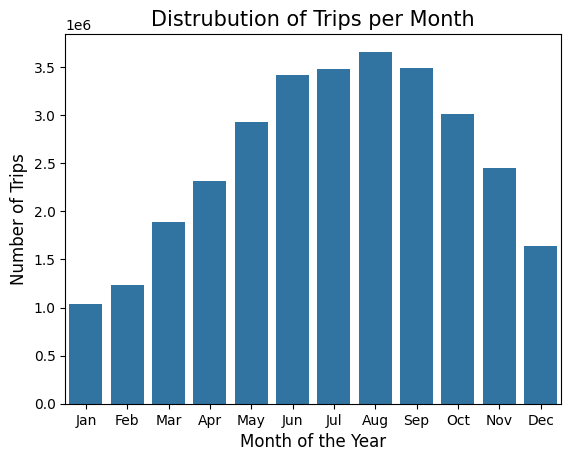

```python
countplot('month', None)
plt.title("Distrubution of Trips per Month", fontsize=15, fontweight='medium');
plt.xlabel('Month of the Year', fontsize=12, fontweight='medium');
plt.ylabel('Number of Trips', fontsize=12, fontweight='medium');
```

> The month shows a very interesting pattern with the weather condition. Cycling have been prefered most in the summer months and least prefered in winter. Generally, there is increase in cycling as we move away from winter and a decrease in cycling as we move towards the winter season.

### Distribution of Ride Duration

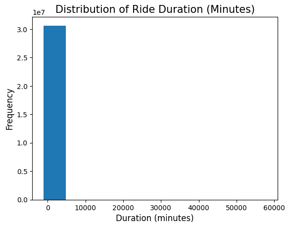

```python
### visualise the distribution of duration across the whole dataset
plt.hist(data = df, x = 'duration_minute')
plt.title("Distribution of Ride Duration (Minutes)", fontsize=15, fontweight='medium')
plt.xlabel('Duration (minutes)',fontsize=12, fontweight='medium' );
plt.ylabel('Frequency',fontsize=12, fontweight='medium');
```

#### Transformation 1

> The distribution shows that we have negative values of duration. This is most likely due to error during entry. lets remove the negative duration from our dataset.

```python
invalid_min = df[df.duration_minute < 0]
df.drop(invalid_min.index, inplace = True)
```

#### Transformation 2

> Nearly all the rides were taken for less than 150 minutes in duration. we will focus mainly on rides within this boundary.

```python
# Remove all ride with duration above 150 minutes
excess_min = df[df.duration_minute > 150]
df.drop(excess_min.index, inplace = True)
```

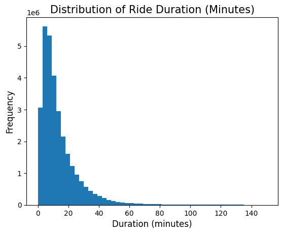

```python
bin_size = 3
bin_edges= np.arange(0, df.duration_minute.max()+bin_size, bin_size)

plt.hist(data = df, x = 'duration_minute', bins = bin_edges)
plt.title("Distribution of Ride Duration (Minutes)", fontsize=15, fontweight='medium')
plt.xlabel('Duration (minutes)',fontsize=12, fontweight='medium')
plt.ylabel('Frequency',fontsize=12, fontweight='medium');
```

> The Initial asssesment of the distribution in duration shows that we had some outliers and some incorrect values. Appropriate manipulation has been done to clear all irregularities. The duration of ride in the study was not greater than 150 minutes (2hrs, 30mins). Most cycling duration was actually less than 20 minutes. This is likely due to speed of cycling and consideration for close proximity.

### What are the Most Popular and the Least Popular Stations.

> These will be examined by checking the start and end end point. it is possible that some station are present in residential areas and thus will be starting point to most occupants. Commercial areas will mostly have workers approaching stations within that area as destination. Lets look into the data to find out more.

#### The most used Start Station

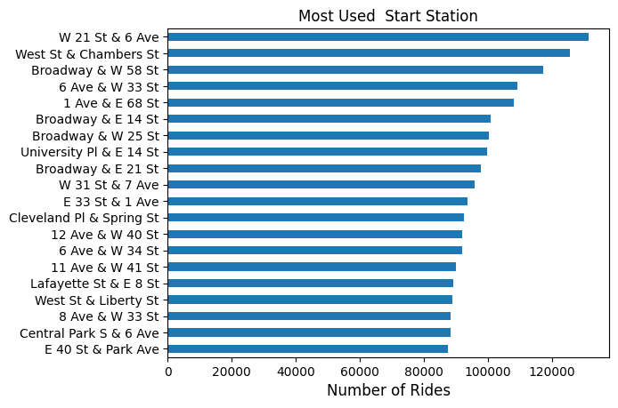

```python
start_stations = df.start_station_name.value_counts()
start_stations.head(20).sort_values(ascending = True).plot(kind = 'barh', title = "Most Used  Start Station")
plt.xlabel('Number of Rides',fontsize=12, fontweight='medium')
```

#### The Least Used Start Station

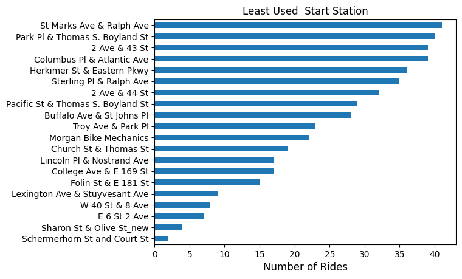

```python
start_stations.tail(20).sort_values(ascending = True).plot(kind = 'barh', title = "Least Used  Start Station")
plt.xlabel('Number of Rides',fontsize=12, fontweight='medium')
```

> These stations show that rides are rearly started from this points. This will mean that there are lesser chances of having a person go to this stations to start a ride.

#### Most Popular Destination

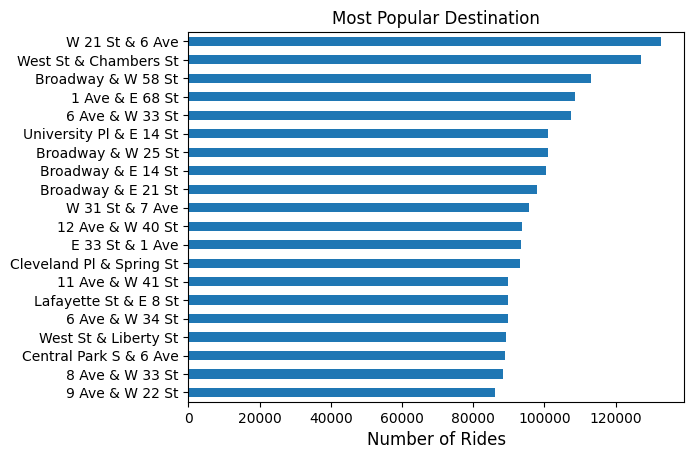

```python
end_stations = df.end_station_name.value_counts()
end_stations.head(20).sort_values(ascending = True).plot(kind = 'barh', title = "Most Popular Destination")
plt.xlabel('Number of Rides',fontsize=12, fontweight='medium')
```

> More focus could be placed in areas were stations have the most cyclers staring and ending their rides. Visualisation actually shows the most popular stations are the places where rides are being started and ended with W21 St and 6 Ave being the most popular of all.

#### The Least Popular Destionation

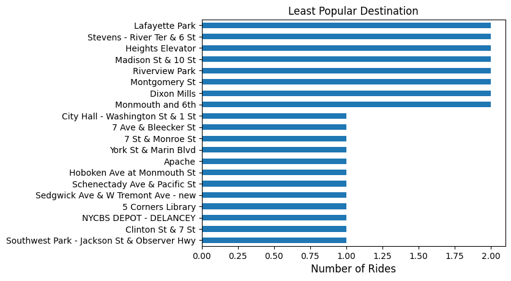

```python
end_stations.tail(20).sort_values(ascending = True).plot(kind = 'barh', title = "Least Popular Destination")
plt.xlabel('Number of Rides',fontsize=12, fontweight='medium')
```

> More strategic decisions could be taken in areas that are less popular e.g Marketing.

### Discuss the distribution(s) of your variable(s) of interest. Were there any unusual points? Did you need to perform any transformations?

> 78% of the total rides ordered were from members with annual subscription in 2022. The most prefered bicycle was the classic bike. cyclers generally prefered short distance ride which mostly do no surpass 20 minutes. The nubers of cyclers decreases in winter and increase from spring to summer.

### Of the features you investigated, were there any unusual distributions? Did you perform any operations on the data to tidy, adjust, or change the form of the data? If so, why did you do this?

> The duration of rides showed unusual distribution. This could have been as aresult of error in inputing information. Values showed negative duration in some places and duration above 24 hours. For this studdy, we considered only duration less than 2hrs 30mins and all negative duration were removed.

## Bivariate Exploration

### Bike Preference for each Subscription Type

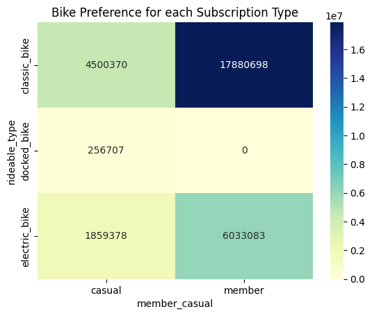

```python
bs_counts = df.groupby(['rideable_type', 'member_casual']).size().reset_index(name='count')
bs_counts = bs_counts.pivot(index = 'rideable_type', columns = 'member_casual', values = 'count')
sb.heatmap(bs_counts, annot = True, fmt = 'd', cmap = 'YlGnBu')
plt.title('Bike Preference for each Subscription Type');
```

> Annual Subscribers do not ride the docked bicycle. Only the casual cyclers tried them in the year 2022. Classic bikes were used the most by both parties.

### Average Duartion of Ride Per Month

```python
duration_avg = df.groupby(['month'])['duration_minute'].mean().reset_index(name = "average_min")
months = ['Jan', 'Feb', 'Mar', 'Apr','May', 'Jun', 'Jul', 'Aug', 'Sep', 'Oct', 'Nov', 'Dec']
duration_avg['month'] = pd.Categorical(duration_avg['month'], categories=months, ordered=True)
duration_avg = duration_avg.sort_values('month')
duration_avg
```

|  | month | average_min |
| --- | --- | --- |
| 4 | Jan | 11.251721 |
| 3 | Feb | 11.837310 |
| 7 | Mar | 12.758322 |
| 0 | Apr | 14.121726 |
| 8 | May | 14.981446 |
| 6 | Jun | 15.121943 |
| 5 | Jul | 14.811812 |
| 1 | Aug | 14.435898 |
| 11 | Sep | 13.970589 |
| 10 | Oct | 13.100441 |
| 9 | Nov | 12.525919 |
| 2 | Dec | 10.962319 |

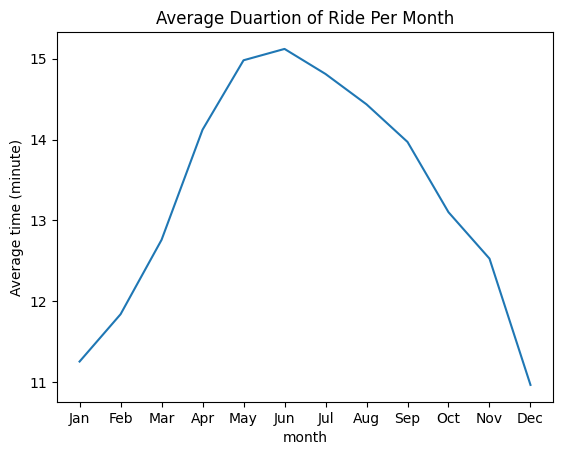

```python
sb.lineplot (data = duration_avg, x = 'month', y = 'average_min')
plt.title('Average Duartion of Ride Per Month')
plt.ylabel('Average time (minute)')
```

> The pattern is similar to the number of rides ordered per month. This similarity follows the weather pattern or the season. Averagely people do not ride for long in winter and will prefer tp ride longer during spring, summer and autumn.

### Average Duartion of Ride for Every Hour of the Day

```python
duration_perhr = df.groupby(['hr_started'])['duration_minute'].mean().reset_index(name = "average_min")

duration_perhr
```

|  | hr_started | average_min |
| --- | --- | --- |
| 0 | 0 | 13.405546 |
| 1 | 1 | 13.297691 |
| 2 | 2 | 13.294363 |
| 3 | 3 | 12.983929 |
| 4 | 4 | 11.882392 |
| 5 | 5 | 10.121712 |
| 6 | 6 | 10.229975 |
| 7 | 7 | 11.088451 |
| 8 | 8 | 11.713264 |
| 9 | 9 | 12.286436 |
| 10 | 10 | 13.666299 |
| 11 | 11 | 14.476422 |
| 12 | 12 | 14.568909 |
| 13 | 13 | 14.758980 |
| 14 | 14 | 15.026872 |
| 15 | 15 | 14.888013 |
| 16 | 16 | 14.599607 |
| 17 | 17 | 14.195167 |
| 18 | 18 | 13.905650 |
| 19 | 19 | 13.758772 |
| 20 | 20 | 13.686729 |
| 21 | 21 | 13.565187 |
| 22 | 22 | 13.596277 |
| 23 | 23 | 13.408799 |

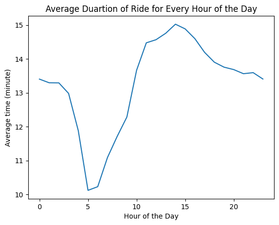

```python
sb.lineplot (data = duration_perhr, x = 'hr_started', y = 'average_min')
plt.title('Average Duartion of Ride for Every Hour of the Day')
plt.ylabel('Average time (minute)')
plt.xlabel('Hour of the Day')
```

### Did you observe any interesting relationships between the other features (not the main feature(s) of interest)?

> No, I was focused on the feautures of interest.

## Multivariate Exploration

### Average Duartion of Ride for Every Hour of the Day for subscribers and non-subscribers

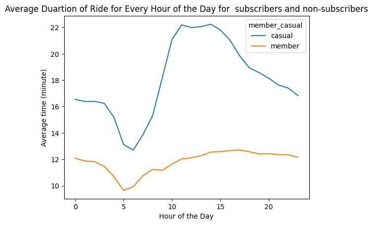

```python
duration_permember = df.groupby(['hr_started','member_casual'])['duration_minute'].mean().reset_index(name = "average_min")

duration_permember
sb.lineplot (data = duration_permember, x = 'hr_started', y = 'average_min', hue = 'member_casual')
plt.title('Average Duartion of Ride for Every Hour of the Day for  subscribers and non-subscribers')
plt.ylabel('Average time (minute)')
plt.xlabel('Hour of the Day')
```

> the pattern is the same for members and casual user which is closely similar to the general observation. Interestingly however, Casual users spend more time cycling than members. This is probably to get the value from their money.

### Distrubution of Trips per Day for Subscribers and non-subscriber

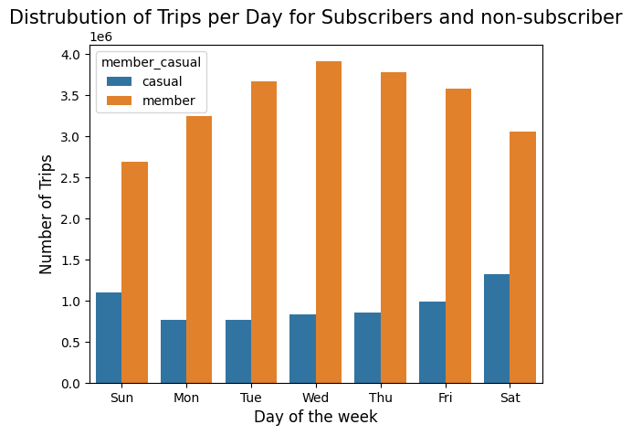

```python
sb.countplot(data=df, x='dow_started', color = base_color, order = days, hue = 'member_casual',  palette=["C0", "C1"] )
plt.title("Distrubution of Trips per Day for Subscribers and non-subscriber", fontsize=15, fontweight='medium')
plt.xlabel('Day of the week', fontsize=12, fontweight='medium')
plt.ylabel('Number of Trips', fontsize=12, fontweight='medium');
```

> The casual cyclers are showing a different daily pattern from the annual subscribers. The casual cyclers mostly prefer weekend rides which is in constrast to the behaviour of the annual subscribers. The fact that casual riders spend more time riding and usually prefer weekends explains the reasons for most causals rides are less likely to be catching up with urgent appointment or issues. It might just be for exercising.

### Talk about some of the relationships you observed in this part of the investigation. Were there features that strengthened each other in terms of looking at your feature(s) of interest?

> the pattern is the same for members and casual user which is shows that cycling activities begin to rise in the morning hours and peaks in the afternoon. The casual bikers mostly use the weekends to cycle.

### Were there any interesting or surprising interactions between features?

> Casual users spend more time cycling than members. This is probably to get the value from their money.

## Conclusions

> Exploration of the 2022 data has uncovered a lot of information about citi bike sharing system. The majority of its patronage comes from annual subscribers making up 78% of its total use for the year. Most of the cyclers prefer using classic bikes to electric bikes and only the casual cyclers ride the docked bike.

> More focus could be placed in areas were stations have the most cyclers staring and ending their rides. Visualisation actually shows the most popular stations are the places where rides are being started and ended with W21 St and 6 Ave being the most popular of all. More strategic decisions could be taken in areas that are less popular e.g Marketing.

```python
df.to_csv('citi_bike_sharing_2022.csv', index = False)
```

### References

1. https://docs.python.org/3/library/datetime.html#strftime-and-strptime-behavior
2. https://www.geeksforgeeks.org/python-timedelta-total_seconds-method-with-example/
3. Udacity Classrooms